# Survival Analysis of Glioblastoma Data

Vasin Dumrongprechachan, PhD

2023-07-11

In this notebook, I will go over the concepts of time-to-event analysis or survival analysis for applications in clinical oncology. The first part introduces the intuitive and mathematical framework of survival analysis. The second part covers examples of non-parametric (KM), parametric (exp, Weinbull), and semi-parametric (Cox).

Overall, this report demonstrates that patients with glioblastoma have greater survival time when they are treated with both chemotherapy and radiation therapy while radiation therapy alone is more effective than chemotherapy alone.

### Brief Concepts of Survival Analysis in Clinical Oncology

**Time-to-event analysis or survival analysis** aims to estimate the expected duration of time until one or more events occur. This is to be contrasted with logistic regression which aims to answer the question whether the event will occur.

In the context of clinical oncology, time-to-event may be any of the following events:

- time to death
- time to response to treatment
- time to relapse/reoccurrence (i.e. remission duration)

However, an individual may leave the study prior to study completion. Therefore, we do not know the answer whether that an event occurs for that patient given the study duration. This type of data is referred to as **right-censored**. Some examples of right-censored scenarios include:

- Fail to follow up
- Withdrawn from study
- Disease progression (opposite effects)
- Event of interest did not occur

Thus, in survival analysis, we do not need all individuals to be present until the completion of the study. Rather, censored observations are used in the dataset up to the time they are censored.

### Theory

Here, we define **survival time** $T$ (or failure time) as a continuous non-negative random variable, representing a time duration from one point to an event of interest.

1. **Survival function** $S(t)$

Suppose $F(t)$ is a cumulative distribution function for the probability of observing $T$ less than or equal to a specified time $t$.
$$F(t) = P(T \leq t) = \int_{0}^{t}{f(s)\cdot
ds}$$
Then, the survival function is defined as the probability of observing $T \geq t$ which is also the complement of $F(t)$ with the initial condition $S(t=0)=1$ and at $S(t \rightarrow \infty) = 0$
$$S(t)=P(T \geq t) = 1 - F(t)$$

2. $S(t)$ is characterized by the **hazard rate function** $h(t)$

$h(t)$ is an instantaneous failure rate (other names: intensity function, force of mortality). In fact, one may say that the shape of $S(t)$ depends on $h(t)$. Although understanding $h(t)$ is quite intuitive, the derived relationship between $h(t)$ and $S(t)$ can be complicated and will be skipped in this notebook.
$$\lambda(t) = h(t)
= \frac{f(t)}{S(t)} = -\frac{d}{dt}\ln(S(t))$$
Note that the common definition of $h(t)$ is usually written in the limit form. Using Bayes’ rule and the differential relationship between PDF ($f(t)$) and CDF ($F(t)$), you can derive the equation above [derivation here](https://towardsdatascience.com/the-mathematical-relationship-between-the-survival-function-and-hazard-function-74559bb6cc34).
$$\lambda(t) = \lim_{dt
\rightarrow \infty} \frac{P(t \leq T <t+dt|T \geq t)}{dt}$$
3. **Cumulative hazard function** $H(t)$ can be derived from integration over $dt$
$$H(t) = \int_{0}^{t} h(u) \cdot du = -\ln(S(t))$$
Thus, we can write the survival function in terms of cumulative hazard function as:
$$S(t) = e^{-H(t)}$$
4. Mean survival is the expected value of survival time

$$\mu = \bar{T} = E(T) =
\int_{0}^{\infty}tf(t)\cdot dt = \int_{0}^{\infty}S(t)\cdot dt$$
Overall, think of $S(t)$ as the not-failing probability and $h(t) \geq 0$ as a conditional failing rate with no upper bound.

### Data Formats

In practice, survival functions are usually step functions with the following format. An indicator variable $d$ is used to denote whether an event has occurred ($d=1$) or an individual has been censored ($d=0$).

| ID | time.wk | status.d | covariates.Eg.Treatment |
| --- | --- | --- | --- |
| 1 | 6 | 0 | chemo |
| 2 | 7 | 1 | radiation |
| 3 | 8 | 0 | both |
| .. | .. | .. | .. |

| ID | time_d | status | treatment | age | sex | race |
| --- | --- | --- | --- | --- | --- | --- |
| TCGA-28-1746 | 6 | 0 | both | 77 | female | white |
| TCGA-14-3476 | 12 | 1 | chemo | 74 | male | white |
| TCGA-28-2502 | 20 | 0 | radiation | 65 | male | white |
| TCGA-14-1043 | 24 | 1 | both | 61 | male | white |
| TCGA-41-2571 | 26 | 1 | chemo | 89 | male | white |
| TCGA-14-1455 | 28 | 1 | chemo | 61 | male | white |

| factor(treatment) | total | num_failed | num_censored |
| --- | --- | --- | --- |
| both | 429 | 345 | 84 |
| chemo | 27 | 26 | 1 |
| radiation | 20 | 16 | 4 |

### R Packages

`survival::Surv(time, status)` creates a response variable for right censored data that can be fitted with functions such as `survfit`(KM), `survreg`(Parametric), and `coxph`(Semi-parametric).

```r
library(survival) # fitting
library(ggsurvfit) # plotting
library(ggfortify) # plotting
library(survminer) # increased functionality
library(flexsurv) # increased functionality
```

### 1. Non-parametric method: Kaplan-Meier Estimator

The function that is used to calculate the Kaplan-Meier estimate is `survfit(formula, data)`. The probability of survival at time $t$ given by the KM estimator is:
$$\widehat{S}_{KM}(t)=\prod_{j:\tau
_j<t}\left ( 1-\frac{d_j}{r_j} \right )$$

- $\tau _j$ is the $j^{th}$ distinct death time
- $d_j$ is the number of death at time $\tau _j$
- $r_j$ is the number of patients who were at risk at time $\tau _j$. Note this also includes those who died at $\tau _j$.

```r
# fit KM model by treatment
s1_KM = survfit(Surv(time_d, status) ~ treatment, data=data_df)
str(s1_KM)
```

```
## List of 17
##  $ n        : int [1:3] 429 27 20
##  $ time     : num [1:399] 6 24 44 47 62 71 76 77 78 82 ...
##  $ n.risk   : num [1:399] 429 428 427 426 424 423 422 421 420 419 ...
##  $ n.event  : num [1:399] 0 1 0 1 1 0 1 1 1 2 ...
##  $ n.censor : num [1:399] 1 0 1 1 0 1 0 0 0 0 ...
##  $ surv     : num [1:399] 1 0.998 0.998 0.995 0.993 ...
##  $ std.err  : num [1:399] 0 0.00234 0.00234 0.00332 0.00407 ...
##  $ cumhaz   : num [1:399] 0 0.00234 0.00234 0.00468 0.00704 ...
##  $ std.chaz : num [1:399] 0 0.00234 0.00234 0.00331 0.00407 ...
##  $ strata   : Named int [1:3] 352 27 20
##   ..- attr(*, "names")= chr [1:3] "treatment=both" "treatment=chemo" "treatment=radiation"
##  $ type     : chr "right"
##  $ logse    : logi TRUE
##  $ conf.int : num 0.95
##  $ conf.type: chr "log"
##  $ lower    : num [1:399] 1 0.993 0.993 0.989 0.985 ...
##  $ upper    : num [1:399] 1 1 1 1 1 ...
##  $ call     : language survfit(formula = Surv(time_d, status) ~ treatment, data = data_df)
##  - attr(*, "class")= chr "survfit"
```

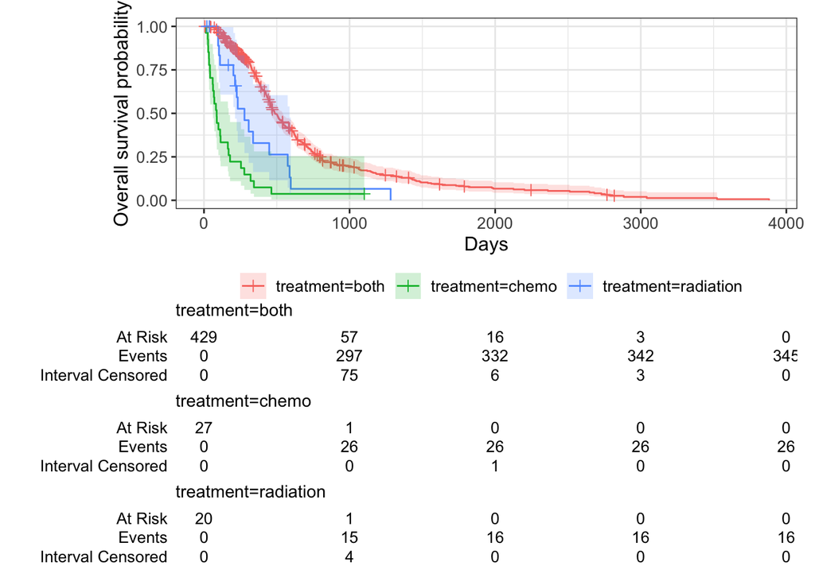

```r
# KM plot by treatment with confidence interval, censorship mark, and risk table
s1_KM %>%
  ggsurvfit() +
  labs(x = "Days", y = "Overall survival probability") +
  add_censor_mark() +
  add_confidence_interval() +
  add_risktable(risktable_stats = c("n.risk", "cum.event", "n.censor"))
```

```r
# the 0.5yr and 1yr survival probability is:
# times = vector of times of interest
# scale = days into year using 365
summary(s1_KM, times =  c(182.5, 365), scale = 365)
```

```
## Call: survfit(formula = Surv(time_d, status) ~ treatment, data = data_df)
##
##                 treatment=both
##  time n.risk n.event survival std.err lower 95% CI upper 95% CI
##   0.5    363      47    0.888  0.0154        0.858        0.918
##   1.0    261      72    0.700  0.0231        0.656        0.747
##
##                 treatment=chemo
##  time n.risk n.event survival std.err lower 95% CI upper 95% CI
##   0.5      6      21   0.2222  0.0800       0.1097        0.450
##   1.0      2       4   0.0741  0.0504       0.0195        0.281
##
##                 treatment=radiation
##  time n.risk n.event survival std.err lower 95% CI upper 95% CI
##   0.5     13       4    0.778   0.098        0.608        0.996
##   1.0      5       7    0.329   0.119        0.162        0.667
```

#### Test for significant difference between survival curves in the KM plot

We can use the log-rank test the null hypothesis that all survival curves are the same. It is based on the Chi-square statistics. It cannot provide an estimate of the effect size or a confidence interval. Other method such as parametric or Cox regression should be used to estimate the difference (e.g., Hazard ratio).

```r
# using log-rank test
survdiff(Surv(time_d, status) ~ treatment, data=data_df)
```

```
## Call:
## survdiff(formula = Surv(time_d, status) ~ treatment, data = data_df)
##
##                       N Observed Expected (O-E)^2/E (O-E)^2/V
## treatment=both      429      345   374.34      2.30     71.28
## treatment=chemo      27       26     4.77     94.41     96.51
## treatment=radiation  20       16     7.88      8.36      8.59
##
##  Chisq= 106  on 2 degrees of freedom, p= <2e-16
```

### 2. Parametric model usually refers to as accelerated failure time (AFT) model

The use of a parametric method is convenient when we are interesting in performing a regression so that we can model the effect of covariates that may affect the inferences of the outcome variable.

> Exponential hazard function

In parametric method, we model the outcome variable based on a statistical distribution. The simplest case here is the exponential distribution, where the hazard function is constant (i.e. constant event rate). Although it is generally too simplistic for human lifetimes.
$$h(t) = \lambda$$
$$S(t) = e^{-\lambda t}$$
$$f(t) = h(t)\cdot S(t)=\lambda e^{-\lambda t}$$
$$E(T) = \int_{0}^{\infty}S(t)
\cdot dt = \frac{1}{\lambda}$$
Now, suppose that we have a dataset of survival $T$ with censorship, assumed to follow a distribution of unknown parameter $\lambda$. One way to estimate such parameter is to used the **maximum likelihood estimator** which can handle censored data well with an indicator variable ($\delta=(0,1)$). Below is a likelihood function:
$$L(\lambda|T_1, T_2, ...,T_n) =
\prod_{i=1}^{n}h(t_i, \lambda)^\delta_{i}\cdot S(t_i,\lambda)^{1-\delta}$$
We can obtain a point estimate of $\lambda$, briefly, by maximizing the likelihood function. But this is difficult while log-transformation $l$ makes it simpler. Calculus tells us that we can solve for $\lambda$ that maximizes $L$ by setting its first derivative equal to 0 (scoring function). On the other hand, the second derivative of this function yields an information function $l = -I(\lambda)$. From statistical theory, variance of $\hat\lambda$ is approximately equal the inverse of information. This can then be used to carry out hypothesis test and CI.
$$\hat{Var}(\hat{\lambda}) \approx
I^{-1}(\hat{\lambda})$$

> Weibull distribution

More realistic distributions that can be used in the same manner with `survreg` are (“weibull”, “exponential”, “gaussian”, “logistic”,“lognormal”, or “loglogistic”). For Weinbull distribution, the survival function is characterized by:
$$h(t) = \alpha \lambda (\lambda t)^{\alpha -1} = \alpha \lambda^{\alpha}
t ^{\alpha - 1}$$
$$S(t) =
e^{-\alpha(\lambda t )}$$

> Modeling without covariates

For parametric modeling, sometimes, it is useful to estimate the hazard function using non-parametric method for visualization. Then, we will use `flexsurv` to estimate the hazard function with different distributions. [Useful article here for more details](https://www.r-bloggers.com/2019/06/parametric-survival-modeling/). This is quite nice because it allows us to inspect which parametric distribution is more appropriate for the data.

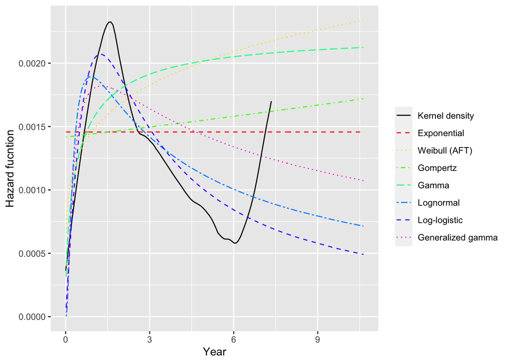

```r
# kernel density estimation
library(muhaz)
haz_kde = muhaz(times = data_df$time_d, delta = data_df$status)
haz_kde_est = data.frame(time = haz_kde$est.grid, est = haz_kde$haz.est, method = 'Kernel density')


# model data with various distribution
dists <- c("exp", "weibull", "gompertz", "gamma", "lognormal", "llogis", "gengamma")
dists_long <- c("Exponential", "Weibull (AFT)","Gompertz", "Gamma", "Lognormal", "Log-logistic",
                "Generalized gamma")
parametric_haz <- vector(mode = "list", length = length(dists))
for (i in 1:length(dists)){
  fit <- flexsurvreg(Surv(time_d, status) ~ 1, data = data_df, dist = dists[i])
  parametric_haz[[i]] <- summary(fit, type = "hazard", ci = FALSE, tidy = TRUE)
  parametric_haz[[i]]$method <- dists_long[i]
}
parametric_haz <- rbindlist(parametric_haz)

# plot hazard function
haz <- rbind(haz_kde_est, parametric_haz)
haz$method = factor(haz$method, levels=c('Kernel density', dists_long))
n_dists <- length(dists)
ggplot(haz, aes(x = time/365, y = est, col = method, linetype = method)) +
  geom_line() +
  xlab("Year") + ylab("Hazard fucntion") +
  scale_colour_manual(name = "", values = c("black", rainbow(n_dists))) +
  scale_linetype_manual(name = "", values = c(1, rep_len(2:6, n_dists)))
```

> Modeling with covariates

One important aspect of using parametric methods is that we can model our data with multiple covariates (this is not exactly the same as stratified KM).

> Estimating the marginal effects of covariates using log-logistic distribution as an example

Sometimes, it’s more intuitive to plot marginal effects to visualize results rather than looking at the regression table. [Check out this article](https://rdrr.io/github/chjackson/flexsurv-dev/f/vignettes/standsurv.Rmd).

```r
# fit log-logistic
s2_llog = flexsurvreg(Surv(time_d, status) ~ treatment + sex + age + race, data=data_df, dist = "llogis")
print(s2_llog)
```

```
## Call:
## flexsurvreg(formula = Surv(time_d, status) ~ treatment + sex +
##     age + race, data = data_df, dist = "llogis")
##
## Estimates:
##                                data mean  est        L95%       U95%
## shape                                 NA   2.29e+00   2.11e+00   2.49e+00
## scale                                 NA   2.35e+03   1.35e+03   4.09e+03
## treatmentchemo                  5.67e-02  -1.57e+00  -1.89e+00  -1.24e+00
## treatmentradiation              4.20e-02  -4.62e-01  -8.37e-01  -8.77e-02
## sexmale                         6.34e-01  -1.18e-01  -2.70e-01   3.32e-02
## age                             5.61e+01  -1.90e-02  -2.44e-02  -1.36e-02
## raceblack or african american   8.40e-02  -3.14e-01  -8.64e-01   2.35e-01
## racewhite                       8.89e-01  -4.07e-01  -8.85e-01   7.11e-02
##                                se         exp(est)   L95%       U95%
## shape                           9.69e-02         NA         NA         NA
## scale                           6.64e+02         NA         NA         NA
## treatmentchemo                  1.65e-01   2.09e-01   1.51e-01   2.88e-01
## treatmentradiation              1.91e-01   6.30e-01   4.33e-01   9.16e-01
## sexmale                         7.74e-02   8.88e-01   7.63e-01   1.03e+00
## age                             2.75e-03   9.81e-01   9.76e-01   9.86e-01
## raceblack or african american   2.80e-01   7.30e-01   4.22e-01   1.27e+00
## racewhite                       2.44e-01   6.66e-01   4.13e-01   1.07e+00
##
## N = 476,  Events: 387,  Censored: 89
## Total time at risk: 265594
## Log-likelihood = -2810.935, df = 8
## AIC = 5637.871
```

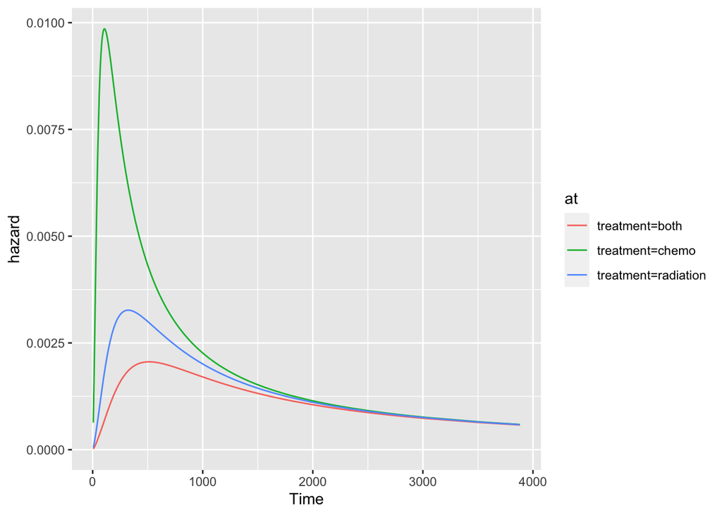

```r
# Estimate mariginal effects of treatment average over other covariates
# for plotting hazard function by treatment accounted for sex, age, race
s2_llog_trt_haz <- standsurv(s2_llog, type = "hazard",
                                  at = list(list(treatment = "both"),
                                            list(treatment = "chemo"),
                                            list(treatment = "radiation")))
plot(s2_llog_trt_haz)
```

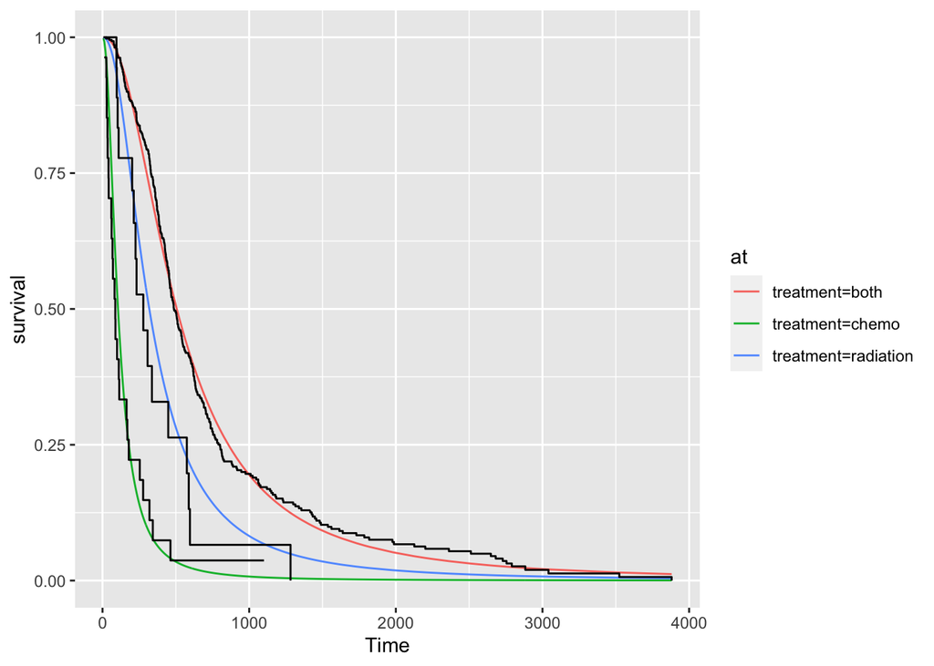

```r
# for plotting survival curves
s2_llog_trt_surv <- standsurv(s2_llog, type = "survival",
                                  at = list(list(treatment = "both"),
                                            list(treatment = "chemo"),
                                            list(treatment = "radiation")))

# combining survival curves
kmsurvplot = ggsurvplot(s1_KM)
plot(s2_llog_trt_surv) + geom_step(aes(x=time, y=surv, group=strata), data=kmsurvplot$data.survplot)
```

### 3. Semi-parametric Cox model

In **Cox proportional hazard model**, the hazard function is modeled in 2 parts:

- the baseline hazard function $h_0(t)$
- the time-independent parametric components assuming multiplicative effects of covariates. Mathematically, this is convenient because coefficients are linearly modeled in the logarithmic scale, allowing **hazard ratio** computation, which is just the exp(coef).

Cox model does not assume the shape of the baseline $h_0(t)$. Therefore, it is not a full parametric model. The parametric part comes from regression-like behavior of the coefficients of the covariates.

$$h(t|X=x)=h_0(t)e^{x^{T}\beta}$$
$$H(t|x) = e^{x^{T}\beta} \int_{0}^{t}h_0(s)
\cdot ds = e^{x^{T}\beta} \cdot H_0(t)$$
$$S(t|x) = e^{x^{T}\beta} \cdot S_0(t)$$
The hazard ratio is an estimate of the ratio of the hazard rate in the treated versus the control group (or a reference group). A HR < 1 indicates reduced hazard of death whereas a HR > 1 indicates an increased hazard of death. It is not a probabiliy, it’s a ratio between rates. In other words, adjusted for other covariates and at a given moment, one group is more likely to experience the event than the other group by HR times.

```r
library(gtsummary)
# fit cox regressioon
s4_cox = coxph(Surv(time_d, status) ~ treatment + sex + age + race, data=data_df)
summary(s4_cox)
```

```
## Call:
## coxph(formula = Surv(time_d, status) ~ treatment + sex + age +
##     race, data = data_df)
##
##   n= 476, number of events= 387
##
##                                   coef exp(coef) se(coef)     z Pr(>|z|)
## treatmentchemo                1.733919  5.662805 0.209623 8.272  < 2e-16 ***
## treatmentradiation            0.707940  2.029807 0.257979 2.744  0.00607 **
## sexmale                       0.228330  1.256500 0.109175 2.091  0.03649 *
## age                           0.026198  1.026544 0.004036 6.491 8.51e-11 ***
## raceblack or african american 0.246666  1.279751 0.431774 0.571  0.56781
## racewhite                     0.507836  1.661691 0.385548 1.317  0.18778
## ---
## Signif. codes:  0 '***' 0.001 '**' 0.01 '*' 0.05 '.' 0.1 ' ' 1
##
##                               exp(coef) exp(-coef) lower .95 upper .95
## treatmentchemo                    5.663     0.1766    3.7549     8.540
## treatmentradiation                2.030     0.4927    1.2242     3.365
## sexmale                           1.257     0.7959    1.0145     1.556
## age                               1.027     0.9741    1.0185     1.035
## raceblack or african american     1.280     0.7814    0.5490     2.983
## racewhite                         1.662     0.6018    0.7805     3.538
##
## Concordance= 0.664  (se = 0.017 )
## Likelihood ratio test= 114.6  on 6 df,   p=<2e-16
## Wald test            = 137.2  on 6 df,   p=<2e-16
## Score (logrank) test = 161.3  on 6 df,   p=<2e-16
```

```r
s4_cox %>% tbl_regression(exp = TRUE)
```

| **Characteristic** | **HR**<sup>1</sup> | **95% CI**<sup>1</sup> | **p-value** |
| --- | --- | --- | --- |
| treatment |  |  |  |
| both | — | — |  |
| chemo | 5.66 | 3.75, 8.54 | <0.001 |
| radiation | 2.03 | 1.22, 3.37 | 0.006 |
| sex |  |  |  |
| female | — | — |  |
| male | 1.26 | 1.01, 1.56 | 0.036 |
| age | 1.03 | 1.02, 1.03 | <0.001 |
| race |  |  |  |
| asian | — | — |  |
| black or african american | 1.28 | 0.55, 2.98 | 0.6 |
| white | 1.66 | 0.78, 3.54 | 0.2 |

<sup>1</sup> HR = Hazard Ratio, CI = Confidence Interval

```r
# checking for the proportional hazard assumption - dependency between covariates residuals and time
# test.ph = cox.zph(s4_cox)
# test.ph
# ggcoxzph(test.ph)
# ggcoxdiagnostics(s4_cox, type = "dfbeta",
#                  linear.predictions = FALSE, ggtheme = theme_bw())


# plotting
# s4_cox_fit = survfit(s4_cox)
# s4_cox_fit %>% autoplot(surv.linetype = 'dashed', surv.colour = 'blue',
#         conf.int.fill = 'dodgerblue3', conf.int.alpha = 0.5, censor = FALSE)
```

### Summary

Although the dataset was simplified for the tutorial purposes, we still uncover many insights about these treatments. 1. Overall, combining chemotherapy and radiation therapy improved survival time of patients. 2. Single type of treatment are associated with increased hazard ratios of 5.66, and 2.03 for chemo and radiation alone, respecitively.

#### Selected References:

1. Dirk F. Moore. Applied Survival Analysis using R.
2. David G. Kleinbaum and Mitchel Klein. Survival Analysis - A Self-Learning Text.
3. https://portal.gdc.cancer.gov/ and http://bioconductor.org/packages/release/bioc/html/TCGAbiolinks.html